# Characteristics of Grants Awarded under FEMA's Pre-Disaster Mitigation Program

Kristina Costa  
December 4, 2019

### Research question

What are the characteristics of U.S. counties that have received Pre-Disaster Mitigation Program (PDM) grants from the Federal Emergency Management Administration (FEMA)?

- PDM grants have been available since FY 2000
- All 50 states, DC, U.S. territories, and tribal areas are eligible
- One of the only federal funding streams for communities to build resilience before natural disasters hit
- Different funding availability over time; $235.2 million available in FY 2018

### Data sources

I drew data from three sources that all needed to be tidied and merged:

- FEMA's [Hazard Mitigation Assistance Projects](https://www.fema.gov/openfema-dataset-hazard-mitigation-assistance-projects-v1) database, which contains the PDM data as well as data for several other grant programs
- FEMA's [Disaster Declarations Summaries](https://www.fema.gov/openfema-dataset-disaster-declarations-summaries-v1) database, which contains dates and descriptions of every major disaster declaration, emergency declaration, and fire management declaration since 1953
- U.S. Census Bureau [American Community Survey 5-year estimates](https://www.census.gov/data/developers/data-sets/acs-5year.html), which contains the most detailed, up-to-date demographic information about Americans, and is accessible at the national, state, county, and city level

### Methods considered

- **To collect data:** I intended to use FEMA and Census Bureau APIs to download the three data sets
  - *Challenges:* The FEMA API returns only 1,000 entries at a time; there have been 20,000 disaster declarations since 2000 alone, and 28,000 observations in the full Hazard Mitigation data set.
- **To manipulate the data:** `dplyr()` functions including `filter()` and `join()`
- **To visualize the data:** `ggplot()` and related packages
- **To analyze the data:** Machine learning functions from `caret()` and related packages

### Methods used to date

- **To collect data:** I ran into considerable challenges with the FEMA APIs, so as a time-saving workaround I downloaded the complete .csv files and used `read.csv()`.
  - I also discovered the `tidycensus()` package, which makes accessing the American Community Survey API a breeze.

### Methods used to date: `tidycensus()`

```r
#Using the tidycensus package to pull ACS 5 year estimates for poverty rate
ACS_pov_dat <- tidycensus::get_acs(geography = "county", variables = "DP03_0119PE",
                                   key = "4b641703e32072356c733cd79067e522979bc17d")

head(ACS_pov_dat)
```

```
# A tibble: 6 x 5
  GEOID NAME                    variable   estimate   moe
  <chr> <chr>                   <chr>         <dbl> <dbl>
1 01001 Autauga County, Alabama DP03_0119P     10.9   2.3
2 01003 Baldwin County, Alabama DP03_0119P      8.2   1.1
3 01005 Barbour County, Alabama DP03_0119P     20.5   2.8
4 01007 Bibb County, Alabama    DP03_0119P     11.9   3
5 01009 Blount County, Alabama  DP03_0119P     11.1   1.5
6 01011 Bullock County, Alabama DP03_0119P     29.7   6.4
```

### Methods used to date

- **To manipulate the data:** FEMA is very inconsistent in how they input data in the Pre-Disaster Mitigation data set, in part because the grants can be given at the federal, state, or local level. Given all the inconsistency, I moved my analysis to the county level.

```r
dat_PDM <- dat_PDM %>%
  mutate(stateNumberCode = sprintf("%02d", stateNumberCode)) %>% #Adding a leading zero where needed
  mutate(countyCode = sprintf("%03d", countyCode)) %>% #Adding two leading zeros where needed
  unite(GEOID, stateNumberCode, countyCode, sep="") #Uniting my mutated fipsCodes to one GEOID
```

### Methods used to date: `tidycensus()`

- **To manipulate the data:** I used `left_join()` to create an ACS data set with all my desired variables, and used `full_join()` to merge the three data sets together by the five-digit GEOID. There are 4,737 observations in my final, combined data set, while there are only 3,220 counties and equivalent units in the U.S. and Puerto Rico.
  - This is because FEMA awards grants and declares disasters in tribal areas not represented in the ACS data, and some locations have received multiple Pre-Disaster Mitigation grants in different years.
- **To analyze the data:** I split my tidied, combined data set using `CreateDataPartition()`.

### Visualizing poverty rate

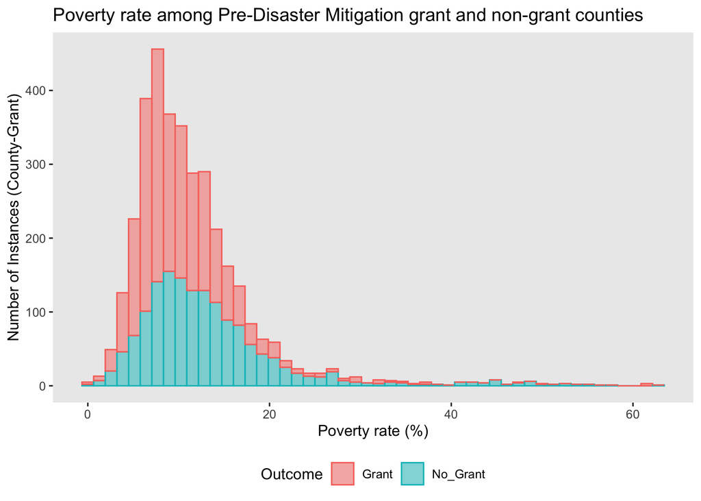

### Visualizing distribution by state

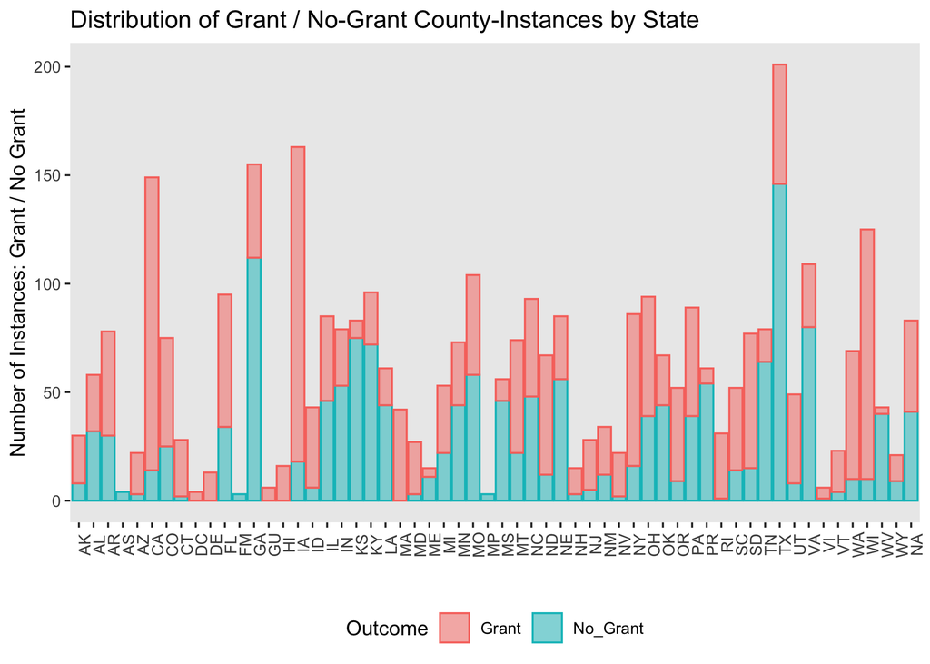

### Visualizing grant amounts

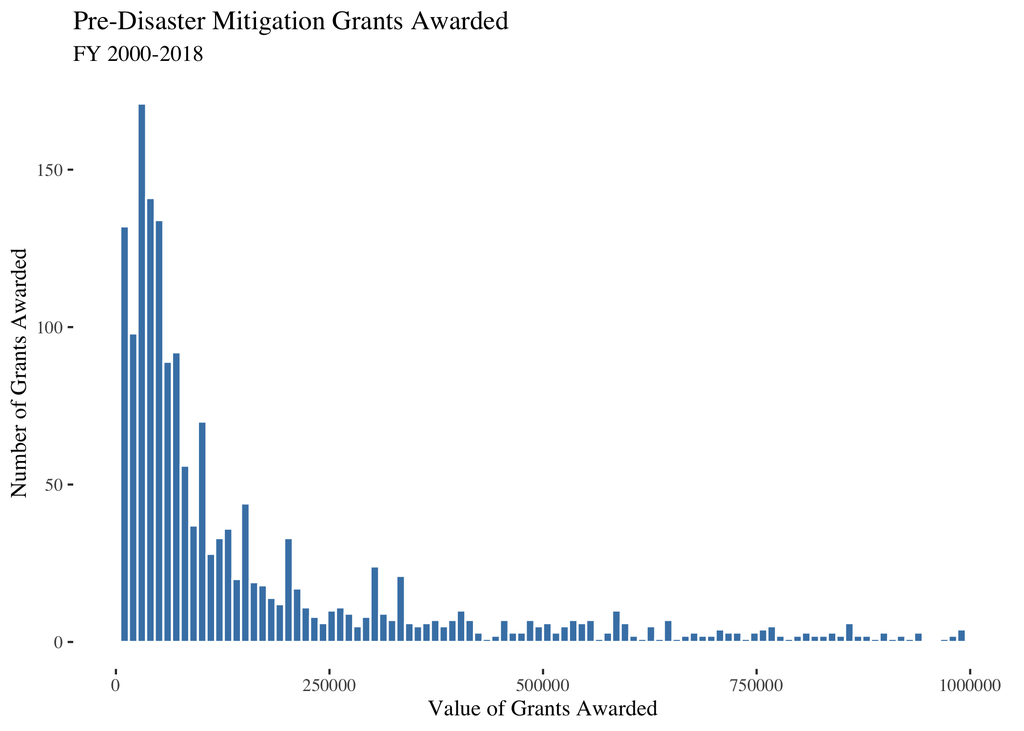

### Initial conclusions

- The poverty data doesn't show much variation between Grant and No_Grant outcomes, so it may not be a particularly useful variable in the machine learning stage.
- On the other hand, there is a decent amount of variation in the number of Grant-county / No_Grant-county instances between states, so there is hope yet that I can actually uncover something interesting.
- I may want to subset the grants by amount (e.g., below $100,000; between $100,000 and $1 million; and $1 million and above) to see if there are any significant differences in poverty rate, racial characteristics, or number of declared disasters in where the different amounts are awarded.

### Coming attractions

- **Machine learning:** I basically have a categorization problem: Grant, or No Grant, so will run my machine learning models accordingly.
  - But despite budgeting considerable time for my data acquisition and wrangling, it took even longer than I expected, so I just haven't been able to complete this phase of the project yet.
- **Map visualizations:** This data set should lend itself well to geographic visualizations… If I can figure out how to use the packages.

### Challenges

- **Data access and wrangling:** I expected it to be challenging, and it was even harder than anticipated, due in large part to FEMA's poor documentation and inconsistent coding.
- **Mapping:** Despite having successfully (I think) downloaded multipolygon geometry codes from ACS, I have not yet been able to get the mapping features in either `ggplot()` or `tmap()`, a specialized thematic mapping package, to work.
  - Receiving error: `Error: stat_sf requires the following missing aesthetics: geometry`
  - I need to dig further into the documentation and perhaps try a test case to see where I'm going wrong.